```python
import pandas as pd
import pandas_profiling

import lightgbm as lgb
from sklearn.metrics import  mean_squared_error

import seaborn as sns
import matplotlib.pyplot as plt
%matplotlib inline

from sklearn.preprocessing import LabelEncoder

from itertools import product
import numpy as np
import gc
import time

from ipywidgets import interact
#%matplotlib notebook
```

# Datos - Objetivo

- Datos diarios de ventas desde Enero 2013 hasta Octubre 2015.
- Para la demo el objetivo es calcular Octubre 2015. Datos de Entrenamiento hasta Septiembre 2015

```python
ts = time.time()
items = pd.read_csv('./DATA/items.csv') # productos  22170
shops = pd.read_csv('./DATA/shops.csv') # tiendas    60
cats = pd.read_csv('./DATA/item_categories.csv') #categorias de los productos 84
train = pd.read_csv('./DATA/sales_train_v2.csv') #ventas diarias  Enero 2013 --> Octubre 2015

test  = pd.read_csv('./DATA/test.csv').set_index('ID') # predicir Noviembre 2015 competición kaggle
time.time() - ts
```

```
2.5503010749816895
```

```python
train.head()
```

|  | date | date_block_num | shop_id | item_id | item_price | item_cnt_day |
| --- | --- | --- | --- | --- | --- | --- |
| 0 | 02.01.2013 | 0 | 59 | 22154 | 999.00 | 1.0 |
| 1 | 03.01.2013 | 0 | 25 | 2552 | 899.00 | 1.0 |
| 2 | 05.01.2013 | 0 | 25 | 2552 | 899.00 | -1.0 |
| 3 | 06.01.2013 | 0 | 25 | 2554 | 1709.05 | 1.0 |
| 4 | 15.01.2013 | 0 | 25 | 2555 | 1099.00 | 1.0 |

```python
train.tail()
```

|  | date | date_block_num | shop_id | item_id | item_price | item_cnt_day |
| --- | --- | --- | --- | --- | --- | --- |
| 2935844 | 10.10.2015 | 33 | 25 | 7409 | 299.0 | 1.0 |
| 2935845 | 09.10.2015 | 33 | 25 | 7460 | 299.0 | 1.0 |
| 2935846 | 14.10.2015 | 33 | 25 | 7459 | 349.0 | 1.0 |
| 2935847 | 22.10.2015 | 33 | 25 | 7440 | 299.0 | 1.0 |
| 2935848 | 03.10.2015 | 33 | 25 | 7460 | 299.0 | 1.0 |

# Objetivo Concurso Kaggle. Calcular Noviembre 2015

```python
test.head() #mes es Noviembre 2015, sólo tiene tienda y producto, pero no precio del producto
```

| ID | shop_id | item_id |
| --- | --- | --- |
| 0 | 5 | 5037 |
| 1 | 5 | 5320 |
| 2 | 5 | 5233 |
| 3 | 5 | 5232 |
| 4 | 5 | 5268 |

```python
#itemsProfile = pandas_profiling.ProfileReport(items)
#itemsProfile.to_file(outputfile="./DATA/items.html")

#shopsProfile = pandas_profiling.ProfileReport(shops)
#shopsProfile.to_file(outputfile="./DATA/shops.html")

#catsProfile = pandas_profiling.ProfileReport(cats)
#catsProfile.to_file(outputfile="./DATA/item_categories.html")

#trainProfile = pandas_profiling.ProfileReport(train)
#trainProfile.to_file(outputfile="./DATA/sales_train_v2.html")

#testProfile = pandas_profiling.ProfileReport(test)
#testProfile.to_file(outputfile="./DATA/test.html")
```

# Outliers - valores atípicos : Son observaciones cuyos valores son muy diferentes a las otras observaciones del mismo grupo de datos

- Gestión de valores nulos: origen, eliminar registros con valores nulos, imputar valores
- Columnas duplicadas ej. km - millas
- Columnas con un valor único
- ...

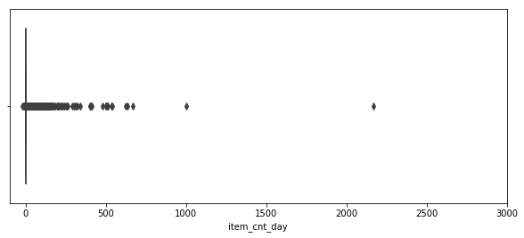

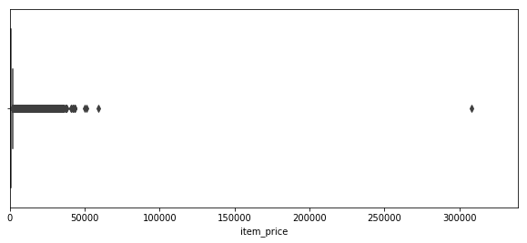

```python
plt.figure(figsize=(10,4))
plt.xlim(-100, 3000)
sns.boxplot(x=train.item_cnt_day)

plt.figure(figsize=(10,4))
plt.xlim(train.item_price.min(), train.item_price.max()*1.1)
sns.boxplot(x=train.item_price)
```

```python
train = train[train.item_price<100000]
train = train[train.item_cnt_day<1001]
```

# Precios negativos

```python
train.loc[train.item_price<0]
```

|  | date | date_block_num | shop_id | item_id | item_price | item_cnt_day |
| --- | --- | --- | --- | --- | --- | --- |
| 484683 | 15.05.2013 | 4 | 32 | 2973 | -1.0 | 1.0 |

```python
# ver otros precios para ese mes, tienda y producto
train[(train.shop_id==32)&(train.item_id==2973)&(train.date_block_num==4)&(train.item_price>0)]
```

|  | date | date_block_num | shop_id | item_id | item_price | item_cnt_day |
| --- | --- | --- | --- | --- | --- | --- |
| 484682 | 23.05.2013 | 4 | 32 | 2973 | 1249.0 | 1.0 |
| 484684 | 06.05.2013 | 4 | 32 | 2973 | 2499.0 | 1.0 |

```python
#asignar la media al precio negativo
median = train[(train.shop_id==32)&(train.item_id==2973)&(train.date_block_num==4)&(train.item_price>0)].item_price.median()
train.loc[train.item_price<0, 'item_price'] = median
print(median)
```

```
1874.0
```

# Tiendas Duplicadas

```python
# Якутск Орджоникидзе, 56
train.loc[train.shop_id == 0, 'shop_id'] = 57
#test.loc[test.shop_id == 0, 'shop_id'] = 57
# Якутск ТЦ "Центральный"
train.loc[train.shop_id == 1, 'shop_id'] = 58
#test.loc[test.shop_id == 1, 'shop_id'] = 58
# Жуковский ул. Чкалова 39м²
train.loc[train.shop_id == 10, 'shop_id'] = 11
#test.loc[test.shop_id == 10, 'shop_id'] = 11
```

# Tratamiento de Tiendas, Categorías y Productos

- Cada nombre de tienda empieza por la ciudad
- Cada categoría contiene el tipo y subtipo en el nombre

```python
shops.head(21)  #Москва --> Moscú
```

|  | shop_name | shop_id |
| --- | --- | --- |
| 0 | !Якутск Орджоникидзе, 56 фран | 0 |
| 1 | !Якутск ТЦ "Центральный" фран | 1 |
| 2 | Адыгея ТЦ "Мега" | 2 |
| 3 | Балашиха ТРК "Октябрь-Киномир" | 3 |
| 4 | Волжский ТЦ "Волга Молл" | 4 |
| 5 | Вологда ТРЦ "Мармелад" | 5 |
| 6 | Воронеж (Плехановская, 13) | 6 |
| 7 | Воронеж ТРЦ "Максимир" | 7 |
| 8 | Воронеж ТРЦ Сити-Парк "Град" | 8 |
| 9 | Выездная Торговля | 9 |
| 10 | Жуковский ул. Чкалова 39м? | 10 |
| 11 | Жуковский ул. Чкалова 39м² | 11 |
| 12 | Интернет-магазин ЧС | 12 |
| 13 | Казань ТЦ "Бехетле" | 13 |
| 14 | Казань ТЦ "ПаркХаус" II | 14 |
| 15 | Калуга ТРЦ "XXI век" | 15 |
| 16 | Коломна ТЦ "Рио" | 16 |
| 17 | Красноярск ТЦ "Взлетка Плаза" | 17 |
| 18 | Красноярск ТЦ "Июнь" | 18 |
| 19 | Курск ТЦ "Пушкинский" | 19 |
| 20 | Москва "Распродажа" | 20 |

```python
ts = time.time()
shops.loc[shops.shop_name == 'Сергиев Посад ТЦ "7Я"', 'shop_name'] = 'СергиевПосад ТЦ "7Я"' #rectificar el nombre de la tienda
shops['city'] = shops['shop_name'].str.split(' ').map(lambda x: x[0]) #dividir el nombre de la tienda por el espacio
shops.loc[shops.city == '!Якутск', 'city'] = 'Якутск'  #rectificar el nombre de la ciudad
shops['city_code'] = LabelEncoder().fit_transform(shops['city']) #codificar las tiendas
shops = shops[['shop_id','city_code']]
time.time() - ts
```

```
0.01173090934753418
```

```python
shops.head(21)
```

|  | shop_id | city_code |
| --- | --- | --- |
| 0 | 0 | 29 |
| 1 | 1 | 29 |
| 2 | 2 | 0 |
| 3 | 3 | 1 |
| 4 | 4 | 2 |
| 5 | 5 | 3 |
| 6 | 6 | 4 |
| 7 | 7 | 4 |
| 8 | 8 | 4 |
| 9 | 9 | 5 |
| 10 | 10 | 6 |
| 11 | 11 | 6 |
| 12 | 12 | 7 |
| 13 | 13 | 8 |
| 14 | 14 | 8 |
| 15 | 15 | 9 |
| 16 | 16 | 10 |
| 17 | 17 | 11 |
| 18 | 18 | 11 |
| 19 | 19 | 12 |
| 20 | 20 | 13 |

```python
cats.head() #Аксессуары - PS2 --> Accesorios PS2
```

|  | item_category_name | item_category_id |
| --- | --- | --- |
| 0 | PC - Гарнитуры/Наушники | 0 |
| 1 | Аксессуары - PS2 | 1 |
| 2 | Аксессуары - PS3 | 2 |
| 3 | Аксессуары - PS4 | 3 |
| 4 | Аксессуары - PSP | 4 |

```python
ts = time.time()
cats['split'] = cats['item_category_name'].str.split('-') #dividir el nombre de la categoría por '-'
cats['type'] = cats['split'].map(lambda x: x[0].strip()) #primera parte tipo de categoría
cats['type_code'] = LabelEncoder().fit_transform(cats['type']) # codificar

cats['subtype'] = cats['split'].map(lambda x: x[1].strip() if len(x) > 1 else x[0].strip()) #segunda parte subtipo
cats['subtype_code'] = LabelEncoder().fit_transform(cats['subtype'])
cats = cats[['item_category_id','type_code', 'subtype_code']]
time.time() - ts
```

```
0.006821632385253906
```

```python
cats.head()
```

|  | item_category_id | type_code | subtype_code |
| --- | --- | --- | --- |
| 0 | 0 | 0 | 29 |
| 1 | 1 | 1 | 9 |
| 2 | 2 | 1 | 10 |
| 3 | 3 | 1 | 11 |
| 4 | 4 | 1 | 13 |

```python
items['item_name'].head(30)
```

```
0             ! ВО ВЛАСТИ НАВАЖДЕНИЯ (ПЛАСТ.)         D
1     !ABBYY FineReader 12 Professional Edition Full...
2         ***В ЛУЧАХ СЛАВЫ   (UNV)                    D
3       ***ГОЛУБАЯ ВОЛНА  (Univ)                      D
4           ***КОРОБКА (СТЕКЛО)                       D
5     ***НОВЫЕ АМЕРИКАНСКИЕ ГРАФФИТИ  (UNI)         ...
6              ***УДАР ПО ВОРОТАМ (UNI)               D
7            ***УДАР ПО ВОРОТАМ-2 (UNI)               D
8              ***ЧАЙ С МУССОЛИНИ                     D
9         ***ШУГАРЛЭНДСКИЙ ЭКСПРЕСС (UNI)             D
10            *ЗА ГРАНЬЮ СМЕРТИ                       D
11            *ЛИНИЯ СМЕРТИ                           D
12                      *МИХЕЙ И ДЖУМАНДЖИ  Сука любовь
13            *СПАСАЯ ЭМИЛИ                           D
14            *ЧОКНУТЫЙ ПРОФЕССОР /МАГИЯ/             D
```

[output cut: 16 more lines]

```python
items.drop(['item_name'], axis=1, inplace=True)
#en esta demo no hacemos uso del nombre del producto, pero se podría crear un diccionario de palabras
```

# Matriz - Todos los productos para todas las tiendas y todos los meses

- hay productos que no aparecen para algunos meses y tiendas, y se deben rellenar con cero
- calcular la suma de ventas por mes - trabajamos por meses
- recortar a 20 es una recondemación de los organizadores del concurso
- rellenar a cero los valores nulos

```python
ts = time.time()
matrix = []
cols = ['date_block_num','shop_id','item_id']
for i in range(34):
    sales = train[train.date_block_num==i]
    matrix.append(np.array(list(product([i], sales.shop_id.unique(), sales.item_id.unique())), dtype='int16'))

matrix = pd.DataFrame(np.vstack(matrix), columns=cols)
matrix['date_block_num'] = matrix['date_block_num'].astype(np.int8)
matrix['shop_id'] = matrix['shop_id'].astype(np.int8)
matrix['item_id'] = matrix['item_id'].astype(np.int16)
matrix.sort_values(cols,inplace=True)

group = train.groupby(['date_block_num','shop_id','item_id']).agg({'item_cnt_day': ['sum']})
group.columns = ['item_cnt_month']
group.reset_index(inplace=True)

matrix = pd.merge(matrix, group, on=cols, how='left')
matrix['item_cnt_month'] = (matrix['item_cnt_month']
                                .fillna(0)
                                .clip(0,20) # NB clip target here
                                .astype(np.float16))

matrix = pd.merge(matrix, shops, on=['shop_id'], how='left')
matrix = pd.merge(matrix, items, on=['item_id'], how='left')
matrix = pd.merge(matrix, cats, on=['item_category_id'], how='left')
matrix['city_code'] = matrix['city_code'].astype(np.int8)
matrix['item_category_id'] = matrix['item_category_id'].astype(np.int8)
matrix['type_code'] = matrix['type_code'].astype(np.int8)
matrix['subtype_code'] = matrix['subtype_code'].astype(np.int8)
time.time() - ts
```

```
25.304773569107056
```

```python
matrix.head()
```

|  | date_block_num | shop_id | item_id | item_cnt_month | city_code | item_category_id | type_code | subtype_code |
| --- | --- | --- | --- | --- | --- | --- | --- | --- |
| 0 | 0 | 2 | 19 | 0.0 | 0 | 40 | 11 | 4 |
| 1 | 0 | 2 | 27 | 1.0 | 0 | 19 | 5 | 10 |
| 2 | 0 | 2 | 28 | 0.0 | 0 | 30 | 8 | 55 |
| 3 | 0 | 2 | 29 | 0.0 | 0 | 23 | 5 | 16 |
| 4 | 0 | 2 | 32 | 0.0 | 0 | 40 | 11 | 4 |

# Crear variables históricas ventas de meses anteriores

```python
def lag_feature(df, lags, col):
    tmp = df[['date_block_num','shop_id','item_id',col]]
    for i in lags:
        shifted = tmp.copy()
        shifted.columns = ['date_block_num','shop_id','item_id', col+'_lag_'+str(i)]
        shifted['date_block_num'] += i
        df = pd.merge(df, shifted, on=['date_block_num','shop_id','item_id'], how='left')
    return df
```

```python
ts = time.time()
matrix = lag_feature(matrix, [1,2,3,6,12], 'item_cnt_month')
time.time() - ts
```

```
39.29626226425171
```

```python
matrix[matrix.date_block_num > 11].head()
```

|  | date_block_num | shop_id | item_id | item_cnt_month | city_code | item_category_id | type_code | subtype_code | item_cnt_month_lag_1 | item_cnt_month_lag_2 | item_cnt_month_lag_3 | item_cnt_month_lag_6 | item_cnt_month_lag_12 |
| --- | --- | --- | --- | --- | --- | --- | --- | --- | --- | --- | --- | --- | --- |
| 4488710 | 12 | 2 | 27 | 0.0 | 0 | 19 | 5 | 10 | 0.0 | 0.0 | 0.0 | 0.0 | 1.0 |
| 4488711 | 12 | 2 | 30 | 0.0 | 0 | 40 | 11 | 4 | 0.0 | 0.0 | 0.0 | 0.0 | NaN |
| 4488712 | 12 | 2 | 31 | 0.0 | 0 | 37 | 11 | 1 | 0.0 | 0.0 | 0.0 | 0.0 | NaN |
| 4488713 | 12 | 2 | 32 | 1.0 | 0 | 40 | 11 | 4 | 0.0 | 0.0 | 0.0 | 0.0 | 0.0 |
| 4488714 | 12 | 2 | 33 | 1.0 | 0 | 37 | 11 | 1 | 1.0 | 2.0 | 0.0 | 0.0 | 1.0 |

# Variables agrupadas (cuidado con la fuga de datos)

La fuga de datos puede hacer que cree modelos predictivos demasiado optimistas, pero realmente son completamente inválidos.

La fuga de datos se produce cuando se utiliza información de fuera del conjunto de datos de capacitación para crear el modelo. Esta información adicional puede permitir que el modelo aprenda o sepa algo que de otro modo no sabría y, a su vez, invalidará el rendimiento estimado del modo que se está construyendo.

```python
ts = time.time()
#la media Nºde ventas agrupado por mes
group = matrix.groupby(['date_block_num']).agg({'item_cnt_month': ['mean']})
group.columns = [ 'date_avg_item_cnt' ]
group.reset_index(inplace=True)
#del mes anterior, se elimina la columna FUGA DE DATOS
matrix = pd.merge(matrix, group, on=['date_block_num'], how='left')
matrix['date_avg_item_cnt'] = matrix['date_avg_item_cnt'].astype(np.float16)
matrix = lag_feature(matrix, [1], 'date_avg_item_cnt')
matrix.drop(['date_avg_item_cnt'], axis=1, inplace=True)

#la media Nºde ventas agrupado por mes y producto
group = matrix.groupby(['date_block_num', 'item_id']).agg({'item_cnt_month': ['mean']})
group.columns = [ 'date_item_avg_item_cnt' ]
group.reset_index(inplace=True)

matrix = pd.merge(matrix, group, on=['date_block_num','item_id'], how='left')
matrix['date_item_avg_item_cnt'] = matrix['date_item_avg_item_cnt'].astype(np.float16)
matrix = lag_feature(matrix, [1,2,3,6,12], 'date_item_avg_item_cnt')
matrix.drop(['date_item_avg_item_cnt'], axis=1, inplace=True)

#la media Nºde ventas agrupado por mes y tienda
group = matrix.groupby(['date_block_num', 'shop_id']).agg({'item_cnt_month': ['mean']})
group.columns = [ 'date_shop_avg_item_cnt' ]
group.reset_index(inplace=True)

matrix = pd.merge(matrix, group, on=['date_block_num','shop_id'], how='left')
matrix['date_shop_avg_item_cnt'] = matrix['date_shop_avg_item_cnt'].astype(np.float16)
matrix = lag_feature(matrix, [1,2,3,6,12], 'date_shop_avg_item_cnt')
matrix.drop(['date_shop_avg_item_cnt'], axis=1, inplace=True)

#la media Nºde ventas agrupado por mes y categoría
group = matrix.groupby(['date_block_num', 'item_category_id']).agg({'item_cnt_month': ['mean']})
group.columns = [ 'date_cat_avg_item_cnt' ]
group.reset_index(inplace=True)

matrix = pd.merge(matrix, group, on=['date_block_num','item_category_id'], how='left')
matrix['date_cat_avg_item_cnt'] = matrix['date_cat_avg_item_cnt'].astype(np.float16)
matrix = lag_feature(matrix, [1], 'date_cat_avg_item_cnt')
matrix.drop(['date_cat_avg_item_cnt'], axis=1, inplace=True)

#la media Nºde ventas agrupado por mes, tienda y  categoría
group = matrix.groupby(['date_block_num', 'shop_id', 'item_category_id']).agg({'item_cnt_month': ['mean']})
group.columns = ['date_shop_cat_avg_item_cnt']
group.reset_index(inplace=True)

matrix = pd.merge(matrix, group, on=['date_block_num', 'shop_id', 'item_category_id'], how='left')
matrix['date_shop_cat_avg_item_cnt'] = matrix['date_shop_cat_avg_item_cnt'].astype(np.float16)
matrix = lag_feature(matrix, [1], 'date_shop_cat_avg_item_cnt')
matrix.drop(['date_shop_cat_avg_item_cnt'], axis=1, inplace=True)

#la media Nºde ventas agrupado por mes, tienda y tipo
group = matrix.groupby(['date_block_num', 'shop_id', 'type_code']).agg({'item_cnt_month': ['mean']})
group.columns = ['date_shop_type_avg_item_cnt']
group.reset_index(inplace=True)

matrix = pd.merge(matrix, group, on=['date_block_num', 'shop_id', 'type_code'], how='left')
matrix['date_shop_type_avg_item_cnt'] = matrix['date_shop_type_avg_item_cnt'].astype(np.float16)
matrix = lag_feature(matrix, [1], 'date_shop_type_avg_item_cnt')
matrix.drop(['date_shop_type_avg_item_cnt'], axis=1, inplace=True)

#la media Nºde ventas agrupado por mes, tienda y subtipo
group = matrix.groupby(['date_block_num', 'shop_id', 'subtype_code']).agg({'item_cnt_month': ['mean']})
group.columns = ['date_shop_subtype_avg_item_cnt']
group.reset_index(inplace=True)

matrix = pd.merge(matrix, group, on=['date_block_num', 'shop_id', 'subtype_code'], how='left')
matrix['date_shop_subtype_avg_item_cnt'] = matrix['date_shop_subtype_avg_item_cnt'].astype(np.float16)
matrix = lag_feature(matrix, [1], 'date_shop_subtype_avg_item_cnt')
matrix.drop(['date_shop_subtype_avg_item_cnt'], axis=1, inplace=True)

#la media Nºde ventas agrupado por mes y ciudad
group = matrix.groupby(['date_block_num', 'city_code']).agg({'item_cnt_month': ['mean']})
group.columns = [ 'date_city_avg_item_cnt' ]
group.reset_index(inplace=True)

matrix = pd.merge(matrix, group, on=['date_block_num', 'city_code'], how='left')
matrix['date_city_avg_item_cnt'] = matrix['date_city_avg_item_cnt'].astype(np.float16)
matrix = lag_feature(matrix, [1], 'date_city_avg_item_cnt')
matrix.drop(['date_city_avg_item_cnt'], axis=1, inplace=True)

#la media Nºde ventas agrupado por mes, producto y ciudad
group = matrix.groupby(['date_block_num', 'item_id', 'city_code']).agg({'item_cnt_month': ['mean']})
group.columns = [ 'date_item_city_avg_item_cnt' ]
group.reset_index(inplace=True)

matrix = pd.merge(matrix, group, on=['date_block_num', 'item_id', 'city_code'], how='left')
matrix['date_item_city_avg_item_cnt'] = matrix['date_item_city_avg_item_cnt'].astype(np.float16)
matrix = lag_feature(matrix, [1], 'date_item_city_avg_item_cnt')
matrix.drop(['date_item_city_avg_item_cnt'], axis=1, inplace=True)

#la media Nºde ventas agrupado por mes y tipo
group = matrix.groupby(['date_block_num', 'type_code']).agg({'item_cnt_month': ['mean']})
group.columns = [ 'date_type_avg_item_cnt' ]
group.reset_index(inplace=True)

matrix = pd.merge(matrix, group, on=['date_block_num', 'type_code'], how='left')
matrix['date_type_avg_item_cnt'] = matrix['date_type_avg_item_cnt'].astype(np.float16)
matrix = lag_feature(matrix, [1], 'date_type_avg_item_cnt')
matrix.drop(['date_type_avg_item_cnt'], axis=1, inplace=True)

#la media Nºde ventas agrupado por mes y subtipo
group = matrix.groupby(['date_block_num', 'subtype_code']).agg({'item_cnt_month': ['mean']})
group.columns = [ 'date_subtype_avg_item_cnt' ]
group.reset_index(inplace=True)

matrix = pd.merge(matrix, group, on=['date_block_num', 'subtype_code'], how='left')
matrix['date_subtype_avg_item_cnt'] = matrix['date_subtype_avg_item_cnt'].astype(np.float16)
matrix = lag_feature(matrix, [1], 'date_subtype_avg_item_cnt')
matrix.drop(['date_subtype_avg_item_cnt'], axis=1, inplace=True)
time.time() - ts
```

```
297.0686810016632
```

```python
matrix[matrix.date_block_num > 11].head()
```

|  | date_block_num | shop_id | item_id | item_cnt_month | city_code | item_category_id | type_code | subtype_code | item_cnt_month_lag_1 | item_cnt_month_lag_2 | ... | date_shop_avg_item_cnt_lag_6 | date_shop_avg_item_cnt_lag_12 | date_cat_avg_item_cnt_lag_1 | date_shop_cat_avg_item_cnt_lag_1 | date_shop_type_avg_item_cnt_lag_1 | date_shop_subtype_avg_item_cnt_lag_1 | date_city_avg_item_cnt_lag_1 | date_item_city_avg_item_cnt_lag_1 | date_type_avg_item_cnt_lag_1 | date_subtype_avg_item_cnt_lag_1 |
| --- | --- | --- | --- | --- | --- | --- | --- | --- | --- | --- | --- | --- | --- | --- | --- | --- | --- | --- | --- | --- | --- |
| 4488710 | 12 | 2 | 27 | 0.0 | 0 | 19 | 5 | 10 | 0.0 | 0.0 | ... | 0.096008 | 0.141235 | 1.082031 | 0.955566 | 0.808594 | 0.935059 | 0.148071 | 0.0 | 1.03418 | 1.075195 |
| 4488711 | 12 | 2 | 30 | 0.0 | 0 | 40 | 11 | 4 | 0.0 | 0.0 | ... | 0.096008 | NaN | 0.291504 | 0.046234 | 0.051727 | 0.046234 | 0.148071 | 0.0 | 0.27002 | 0.291504 |
| 4488712 | 12 | 2 | 31 | 0.0 | 0 | 37 | 11 | 1 | 0.0 | 0.0 | ... | 0.096008 | NaN | 0.232788 | 0.059448 | 0.051727 | 0.064697 | 0.148071 | 0.0 | 0.27002 | 0.234009 |
| 4488713 | 12 | 2 | 32 | 1.0 | 0 | 40 | 11 | 4 | 0.0 | 0.0 | ... | 0.096008 | 0.141235 | 0.291504 | 0.046234 | 0.051727 | 0.046234 | 0.148071 | 0.0 | 0.27002 | 0.291504 |
| 4488714 | 12 | 2 | 33 | 1.0 | 0 | 37 | 11 | 1 | 1.0 | 2.0 | ... | 0.096008 | 0.141235 | 0.232788 | 0.059448 | 0.051727 | 0.064697 | 0.148071 | 1.0 | 0.27002 | 0.234009 |

5 rows × 32 columns

# Tendencia de precios en los últimos seis meses.

## Delta Precio = (Precio Medio Producto agrupado por mes - Precio Medio Producto) / Precio Medio Producto

```python
ts = time.time()
group = train.groupby(['item_id']).agg({'item_price': ['mean']})
group.columns = ['item_avg_item_price']
group.reset_index(inplace=True)

matrix = pd.merge(matrix, group, on=['item_id'], how='left')
matrix['item_avg_item_price'] = matrix['item_avg_item_price'].astype(np.float16)

group = train.groupby(['date_block_num','item_id']).agg({'item_price': ['mean']})
group.columns = ['date_item_avg_item_price']
group.reset_index(inplace=True)

matrix = pd.merge(matrix, group, on=['date_block_num','item_id'], how='left')
matrix['date_item_avg_item_price'] = matrix['date_item_avg_item_price'].astype(np.float16)

lags = [1,2,3,4,5,6]
matrix = lag_feature(matrix, lags, 'date_item_avg_item_price')

for i in lags:
    matrix['delta_price_lag_'+str(i)] = \
        (matrix['date_item_avg_item_price_lag_'+str(i)] - matrix['item_avg_item_price']) / matrix['item_avg_item_price']

#primer histórico distinto de cero, partimos que no tenemos el precio de los productos para el mes de validación
def select_trend(row):
    for i in lags:
        if row['delta_price_lag_'+str(i)]:
            return row['delta_price_lag_'+str(i)]
    return 0

matrix['delta_price_lag'] = matrix.apply(select_trend, axis=1)
matrix['delta_price_lag'] = matrix['delta_price_lag'].astype(np.float16)
matrix['delta_price_lag'].fillna(0, inplace=True)

fetures_to_drop = ['item_avg_item_price', 'date_item_avg_item_price']
for i in lags:
    fetures_to_drop += ['date_item_avg_item_price_lag_'+str(i)]
    fetures_to_drop += ['delta_price_lag_'+str(i)]

matrix.drop(fetures_to_drop, axis=1, inplace=True)
time.time() - ts
```

```
356.799968957901
```

```python
matrix.head()
```

|  | date_block_num | shop_id | item_id | item_cnt_month | city_code | item_category_id | type_code | subtype_code | item_cnt_month_lag_1 | item_cnt_month_lag_2 | ... | date_shop_avg_item_cnt_lag_12 | date_cat_avg_item_cnt_lag_1 | date_shop_cat_avg_item_cnt_lag_1 | date_shop_type_avg_item_cnt_lag_1 | date_shop_subtype_avg_item_cnt_lag_1 | date_city_avg_item_cnt_lag_1 | date_item_city_avg_item_cnt_lag_1 | date_type_avg_item_cnt_lag_1 | date_subtype_avg_item_cnt_lag_1 | delta_price_lag |
| --- | --- | --- | --- | --- | --- | --- | --- | --- | --- | --- | --- | --- | --- | --- | --- | --- | --- | --- | --- | --- | --- |
| 0 | 0 | 2 | 19 | 0.0 | 0 | 40 | 11 | 4 | NaN | NaN | ... | NaN | NaN | NaN | NaN | NaN | NaN | NaN | NaN | NaN | 0.0 |
| 1 | 0 | 2 | 27 | 1.0 | 0 | 19 | 5 | 10 | NaN | NaN | ... | NaN | NaN | NaN | NaN | NaN | NaN | NaN | NaN | NaN | 0.0 |
| 2 | 0 | 2 | 28 | 0.0 | 0 | 30 | 8 | 55 | NaN | NaN | ... | NaN | NaN | NaN | NaN | NaN | NaN | NaN | NaN | NaN | 0.0 |
| 3 | 0 | 2 | 29 | 0.0 | 0 | 23 | 5 | 16 | NaN | NaN | ... | NaN | NaN | NaN | NaN | NaN | NaN | NaN | NaN | NaN | 0.0 |
| 4 | 0 | 2 | 32 | 0.0 | 0 | 40 | 11 | 4 | NaN | NaN | ... | NaN | NaN | NaN | NaN | NaN | NaN | NaN | NaN | NaN | 0.0 |

5 rows × 33 columns

# Tendencia de ingresos de la tienda del mes pasado

```python
ts = time.time()
train['revenue'] = train['item_price'] *  train['item_cnt_day'] #ingresos precio * ventas

group = train.groupby(['date_block_num','shop_id']).agg({'revenue': ['sum']})
group.columns = ['date_shop_revenue']
group.reset_index(inplace=True)

matrix = pd.merge(matrix, group, on=['date_block_num','shop_id'], how='left')
matrix['date_shop_revenue'] = matrix['date_shop_revenue'].astype(np.float32)

group = group.groupby(['shop_id']).agg({'date_shop_revenue': ['mean']})
group.columns = ['shop_avg_revenue']
group.reset_index(inplace=True)

matrix = pd.merge(matrix, group, on=['shop_id'], how='left')
matrix['shop_avg_revenue'] = matrix['shop_avg_revenue'].astype(np.float32)

matrix['delta_revenue'] = (matrix['date_shop_revenue'] - matrix['shop_avg_revenue']) / matrix['shop_avg_revenue']
matrix['delta_revenue'] = matrix['delta_revenue'].astype(np.float16)

matrix = lag_feature(matrix, [1], 'delta_revenue')

matrix.drop(['date_shop_revenue','shop_avg_revenue','delta_revenue'], axis=1, inplace=True)
time.time() - ts
```

```
24.887163162231445
```

```python
matrix.head()
```

|  | date_block_num | shop_id | item_id | item_cnt_month | city_code | item_category_id | type_code | subtype_code | item_cnt_month_lag_1 | item_cnt_month_lag_2 | ... | date_cat_avg_item_cnt_lag_1 | date_shop_cat_avg_item_cnt_lag_1 | date_shop_type_avg_item_cnt_lag_1 | date_shop_subtype_avg_item_cnt_lag_1 | date_city_avg_item_cnt_lag_1 | date_item_city_avg_item_cnt_lag_1 | date_type_avg_item_cnt_lag_1 | date_subtype_avg_item_cnt_lag_1 | delta_price_lag | delta_revenue_lag_1 |
| --- | --- | --- | --- | --- | --- | --- | --- | --- | --- | --- | --- | --- | --- | --- | --- | --- | --- | --- | --- | --- | --- |
| 0 | 0 | 2 | 19 | 0.0 | 0 | 40 | 11 | 4 | NaN | NaN | ... | NaN | NaN | NaN | NaN | NaN | NaN | NaN | NaN | 0.0 | NaN |
| 1 | 0 | 2 | 27 | 1.0 | 0 | 19 | 5 | 10 | NaN | NaN | ... | NaN | NaN | NaN | NaN | NaN | NaN | NaN | NaN | 0.0 | NaN |
| 2 | 0 | 2 | 28 | 0.0 | 0 | 30 | 8 | 55 | NaN | NaN | ... | NaN | NaN | NaN | NaN | NaN | NaN | NaN | NaN | 0.0 | NaN |
| 3 | 0 | 2 | 29 | 0.0 | 0 | 23 | 5 | 16 | NaN | NaN | ... | NaN | NaN | NaN | NaN | NaN | NaN | NaN | NaN | 0.0 | NaN |
| 4 | 0 | 2 | 32 | 0.0 | 0 | 40 | 11 | 4 | NaN | NaN | ... | NaN | NaN | NaN | NaN | NaN | NaN | NaN | NaN | 0.0 | NaN |

5 rows × 34 columns

# Mes y nº días

```python
matrix['month'] = matrix['date_block_num'] % 12


days = pd.Series([31,28,31,30,31,30,31,31,30,31,30,31])
matrix['days'] = matrix['month'].map(days).astype(np.int8)
```

# Nº meses desde la última venta por producto y tienda, y por producto

```python
ts = time.time()
cache = {}
matrix['item_shop_last_sale'] = -1
matrix['item_shop_last_sale'] = matrix['item_shop_last_sale'].astype(np.int8)
for idx, row in matrix.iterrows():
    key = str(row.item_id)+' '+str(row.shop_id) #por producto y tienda
    if key not in cache:
        if row.item_cnt_month!=0:
            cache[key] = row.date_block_num
    else:
        last_date_block_num = cache[key]
        matrix.at[idx, 'item_shop_last_sale'] = row.date_block_num - last_date_block_num
        cache[key] = row.date_block_num

matrix['item_last_sale'] = -1
matrix['item_last_sale'] = matrix['item_last_sale'].astype(np.int8)
for idx, row in matrix.iterrows():
    key = row.item_id  #solo por producto
    if key not in cache:
        if row.item_cnt_month!=0:
            cache[key] = row.date_block_num
    else:
        last_date_block_num = cache[key]
        if row.date_block_num>last_date_block_num:
            matrix.at[idx, 'item_last_sale'] = row.date_block_num - last_date_block_num
            cache[key] = row.date_block_num
time.time() - ts
```

```
1779.9424085617065
```

# Nº meses desde la primera venta por producto y tienda, y por producto

```python
ts = time.time()
matrix['item_shop_first_sale'] = matrix['date_block_num'] - matrix.groupby(['item_id','shop_id'])['date_block_num'].transform('min')
matrix['item_first_sale'] = matrix['date_block_num'] - matrix.groupby('item_id')['date_block_num'].transform('min')
time.time() - ts
```

```
3.4183311462402344
```

# Quitamos los primeres 12 meses

## No tienen valores históricos

```python
matrix = matrix[matrix.date_block_num > 11]
```

# Rellenamos a cero posibles valores a nulo

```python
ts = time.time()
def fill_na(df):
    for col in df.columns:
        if ('_lag_' in col) & (df[col].isnull().any()):
            if ('item_cnt' in col):
                df[col].fillna(0, inplace=True)
    return df

matrix = fill_na(matrix)
time.time() - ts
```

```
5.6705322265625
```

```python
matrix.head()
```

|  | date_block_num | shop_id | item_id | item_cnt_month | city_code | item_category_id | type_code | subtype_code | item_cnt_month_lag_1 | item_cnt_month_lag_2 | ... | date_type_avg_item_cnt_lag_1 | date_subtype_avg_item_cnt_lag_1 | delta_price_lag | delta_revenue_lag_1 | month | days | item_shop_last_sale | item_last_sale | item_shop_first_sale | item_first_sale |
| --- | --- | --- | --- | --- | --- | --- | --- | --- | --- | --- | --- | --- | --- | --- | --- | --- | --- | --- | --- | --- | --- |
| 4488710 | 12 | 2 | 27 | 0.0 | 0 | 19 | 5 | 10 | 0.0 | 0.0 | ... | 1.03418 | 1.075195 | -0.282715 | 1.211914 | 0 | 31 | 1 | 1 | 12 | 12 |
| 4488711 | 12 | 2 | 30 | 0.0 | 0 | 40 | 11 | 4 | 0.0 | 0.0 | ... | 0.27002 | 0.291504 | -0.483398 | 1.211914 | 0 | 31 | 1 | 1 | 11 | 11 |
| 4488712 | 12 | 2 | 31 | 0.0 | 0 | 37 | 11 | 1 | 0.0 | 0.0 | ... | 0.27002 | 0.234009 | -0.137451 | 1.211914 | 0 | 31 | 1 | 1 | 11 | 11 |
| 4488713 | 12 | 2 | 32 | 1.0 | 0 | 40 | 11 | 4 | 0.0 | 0.0 | ... | 0.27002 | 0.291504 | -0.407227 | 1.211914 | 0 | 31 | -1 | 1 | 12 | 12 |
| 4488714 | 12 | 2 | 33 | 1.0 | 0 | 37 | 11 | 1 | 1.0 | 2.0 | ... | 0.27002 | 0.234009 | -0.225464 | 1.211914 | 0 | 31 | 1 | 1 | 12 | 12 |

5 rows × 40 columns

```python
matrix.columns
```

```
Index(['date_block_num', 'shop_id', 'item_id', 'item_cnt_month', 'city_code',
       'item_category_id', 'type_code', 'subtype_code', 'item_cnt_month_lag_1',
       'item_cnt_month_lag_2', 'item_cnt_month_lag_3', 'item_cnt_month_lag_6',
       'item_cnt_month_lag_12', 'date_avg_item_cnt_lag_1',
       'date_item_avg_item_cnt_lag_1', 'date_item_avg_item_cnt_lag_2',
       'date_item_avg_item_cnt_lag_3', 'date_item_avg_item_cnt_lag_6',
       'date_item_avg_item_cnt_lag_12', 'date_shop_avg_item_cnt_lag_1',
       'date_shop_avg_item_cnt_lag_2', 'date_shop_avg_item_cnt_lag_3',
       'date_shop_avg_item_cnt_lag_6', 'date_shop_avg_item_cnt_lag_12',
       'date_cat_avg_item_cnt_lag_1', 'date_shop_cat_avg_item_cnt_lag_1',
       'date_shop_type_avg_item_cnt_lag_1',
       'date_shop_subtype_avg_item_cnt_lag_1', 'date_city_avg_item_cnt_lag_1',
       'date_item_city_avg_item_cnt_lag_1', 'date_type_avg_item_cnt_lag_1',
       'date_subtype_avg_item_cnt_lag_1', 'delta_price_lag',
       'delta_revenue_lag_1', 'month', 'days', 'item_shop_last_sale',
       'item_last_sale', 'item_shop_first_sale', 'item_first_sale'],
      dtype='object')
```

```python
matrix.info()
```

```
<class 'pandas.core.frame.DataFrame'>
Int64Index: 6425094 entries, 4488710 to 10913803
Data columns (total 40 columns):
date_block_num                          int8
shop_id                                 int8
item_id                                 int16
item_cnt_month                          float16
city_code                               int8
item_category_id                        int8
type_code                               int8
subtype_code                            int8
item_cnt_month_lag_1                    float16
item_cnt_month_lag_2                    float16
item_cnt_month_lag_3                    float16
item_cnt_month_lag_6                    float16
item_cnt_month_lag_12                   float16
date_avg_item_cnt_lag_1                 float16
date_item_avg_item_cnt_lag_1            float16
date_item_avg_item_cnt_lag_2            float16
date_item_avg_item_cnt_lag_3            float16
date_item_avg_item_cnt_lag_6            float16
date_item_avg_item_cnt_lag_12           float16
date_shop_avg_item_cnt_lag_1            float16
date_shop_avg_item_cnt_lag_2            float16
date_shop_avg_item_cnt_lag_3            float16
date_shop_avg_item_cnt_lag_6            float16
date_shop_avg_item_cnt_lag_12           float16
date_cat_avg_item_cnt_lag_1             float16
date_shop_cat_avg_item_cnt_lag_1        float16
date_shop_type_avg_item_cnt_lag_1       float16
date_shop_subtype_avg_item_cnt_lag_1    float16
date_city_avg_item_cnt_lag_1            float16
date_item_city_avg_item_cnt_lag_1       float16
date_type_avg_item_cnt_lag_1            float16
date_subtype_avg_item_cnt_lag_1         float16
delta_price_lag                         float16
delta_revenue_lag_1                     float16
month                                   int8
days                                    int8
item_shop_last_sale                     int8
item_last_sale                          int8
item_shop_first_sale                    int8
item_first_sale                         int8
dtypes: float16(27), int16(1), int8(12)
memory usage: 465.7 MB
```

```python
ts = time.time()
matrix.to_pickle('./DATA/data.pkl')

del matrix
del group
del items
del shops
del cats
del train
del cache

gc.collect();
time.time() - ts
```

```
2.950373411178589
```

# Separación de datos de entrenamiento y validación

```python
ts = time.time()
data = pd.read_pickle('./DATA/data.pkl')
X_train = data[data.date_block_num < 33].drop(['item_cnt_month'], axis=1)
Y_train = data[data.date_block_num < 33]['item_cnt_month']
X_valid = data[data.date_block_num == 33].drop(['item_cnt_month'], axis=1)
Y_valid = data[data.date_block_num == 33]['item_cnt_month']
time.time() - ts
```

```
3.2833664417266846
```

# Entrenamiento

```python
ts = time.time()
'''
#0.7875788072832439
params = {'bagging_fraction': 0.99, 'bagging_freq': 8, 'bagging_seed': SEED,
          'feature_fraction': 0.6802441991432773, 'feature_fraction_seed': SEED,
          'lambda_l1': 200, 'lambda_l2': 200, 'learning_rate': 0.015, 'max_bin': 176,
          'metric': 'rmse', 'min_child_samples': 656,
          'min_child_weight': 636, 'min_split_gain': 0.1512409762978552, 'nthread': 8,
          'num_leaves': 454, 'objective': 'mse', 'verbose': 0}
'''
SEED = 3246584
#0.7838050006725876
params = {'bagging_fraction': 0.5923685197548111, 'bagging_freq': 8, 'bagging_seed': SEED,
          'feature_fraction': 0.6471558662772907, 'feature_fraction_seed': SEED,
          'lambda_l1': 8, 'lambda_l2': 454, 'learning_rate': 0.15007983998456081, 'max_bin': 899,
          'metric': 'rmse', 'min_child_samples': 463,
          'min_child_weight': 578, 'min_split_gain': 0.21257474291512948, 'nthread': 8,
          'num_leaves': 278, 'objective': 'mse', 'verbose': 0}




evals_result = {}
model = lgb.train(params,
            train_set=lgb.Dataset(X_train, label=Y_train),
            num_boost_round=50000,
            valid_sets=[lgb.Dataset(X_train, label=Y_train), lgb.Dataset(X_valid, label=Y_valid)] ,
            valid_names=['train', 'val'],
            evals_result=evals_result,
            verbose_eval=50,
            early_stopping_rounds=400)
time.time() - ts
```

[output not shown]

```
384.1255531311035
```

```
Plotting metrics recorded during training...
```

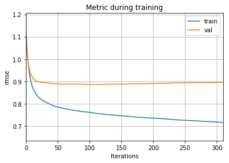

```python
print('Plotting metrics recorded during training...')
ax = lgb.plot_metric(evals_result, metric='rmse')
plt.show()
```

```
Plotting feature importances...
```

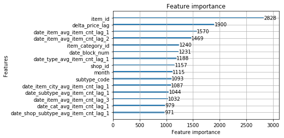

```python
print('Plotting feature importances...')
ax = lgb.plot_importance(model, max_num_features=15)
plt.show()
```

[figure not shown]

```python
ax = lgb.plot_tree(model, tree_index=0, figsize=(20, 8), show_info=['split_gain'])
plt.show()
```

```python
for i in range(4):
    graph = lgb.create_tree_digraph(model, tree_index=i, name='./TREES/Tree' + str(i))
    graph.render(view=False)
```

# Predicción

```python
Y_valid_predict = model.predict(X_valid, num_iteration=model.best_iteration).clip(0, 20)

rmseAux = mean_squared_error(Y_valid, Y_valid_predict)
print (rmseAux)

submission = pd.DataFrame({
    "shop_id": X_valid['shop_id'],
    "item_id": X_valid['item_id'],
    "item_cnt_month": Y_valid,
    "predict": Y_valid_predict,
    "predict_round": Y_valid_predict.round(),
    "difference": (Y_valid - Y_valid_predict.round())
})
submission.to_csv('lgb_submission.csv', index=False)
```

```
0.7838050006725876
```

```python
submission['difference'].describe()
```

```
count    238172.000000
mean          0.059915
std           0.902847
min         -15.000000
25%           0.000000
50%           0.000000
75%           0.000000
max          20.000000
Name: difference, dtype: float64
```

```python
print ("Nº registros: ", submission['difference'].count())
print ("Nº aciertos: ", submission[submission.difference == 0]['difference'].count())
```

```
Nº registros:  238172
Nº aciertos:  199420
```

```python
submission[submission.item_cnt_month > 3].sample(20, random_state =3333) #101, 5555, 3333
```

|  | shop_id | item_id | item_cnt_month | predict | predict_round | difference |
| --- | --- | --- | --- | --- | --- | --- |
| 10883719 | 53 | 10202 | 13.0 | 5.412637 | 5.0 | 8.0 |
| 10734084 | 15 | 17717 | 13.0 | 12.937701 | 13.0 | 0.0 |
| 10693296 | 5 | 5675 | 7.0 | 2.629981 | 3.0 | 4.0 |
| 10711439 | 9 | 13703 | 4.0 | 1.665901 | 2.0 | 2.0 |
| 10784462 | 28 | 2576 | 8.0 | 1.004106 | 1.0 | 7.0 |
| 10889791 | 55 | 13097 | 20.0 | 20.000000 | 20.0 | 0.0 |
| 10730279 | 15 | 2308 | 6.0 | 4.079927 | 4.0 | 2.0 |
| 10762612 | 22 | 1583 | 20.0 | 6.336269 | 6.0 | 14.0 |
| 10818766 | 38 | 10207 | 6.0 | 2.901029 | 3.0 | 3.0 |
| 10857458 | 47 | 13340 | 7.0 | 3.757670 | 4.0 | 3.0 |
| 10822564 | 39 | 3351 | 7.0 | 9.946189 | 10.0 | -3.0 |
| 10697266 | 5 | 22092 | 4.0 | 1.610907 | 2.0 | 2.0 |
| 10759218 | 21 | 10200 | 5.0 | 2.585797 | 3.0 | 2.0 |
| 10789572 | 31 | 1201 | 5.0 | 1.480671 | 1.0 | 4.0 |
| 10792536 | 31 | 13457 | 4.0 | 3.275115 | 3.0 | 1.0 |
| 10775026 | 25 | 8219 | 4.0 | 2.410940 | 2.0 | 2.0 |
| 10746541 | 19 | 2422 | 5.0 | 2.525657 | 3.0 | 2.0 |
| 10779922 | 26 | 5822 | 4.0 | 7.496901 | 7.0 | -3.0 |
| 10800738 | 35 | 2753 | 4.0 | 2.758664 | 3.0 | 1.0 |
| 10855869 | 47 | 6497 | 4.0 | 2.308746 | 2.0 | 2.0 |

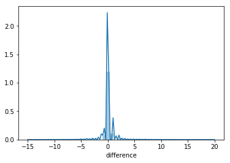

```python
 ax = sns.distplot(submission['difference'])
```

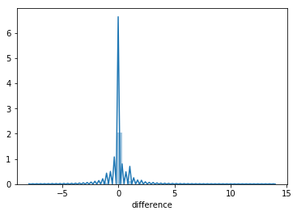

```python
ax = sns.distplot(submission[submission.shop_id == 2]['difference'])
```

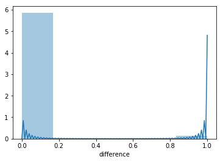

```python
ax = sns.distplot(submission[submission.item_id == 30]['difference'])
```

```python
shops = sorted(submission['shop_id'].unique().tolist())

@interact(shopid=shops)
def DiffShops(shopid):
     ax = sns.distplot(submission[submission.shop_id == shopid]['difference'])
```

```python
items = sorted(submission['item_id'].unique().tolist())

@interact(itemid=items)
def DiffItems(itemid):
     ax = sns.distplot(submission[submission.item_id == itemid]['difference'])
```